# Python Basics

# Pandas

Library providing high-performance, easy-to-use data structures and data analysis tools for Python. Pandas runs on top of numpy, and is very popular for data science.

### Installation

```python
!pip install pandas

import pandas as pd
```

### Reading data

```python
df = pd.read_csv('winequality-white.csv', delimiter = ';')

# Prints the first 10 rows
df.head(10)
```

|  | fixed acidity | volatile acidity | citric acid | residual sugar | chlorides | free sulfur dioxide | total sulfur dioxide | density | pH | sulphates | alcohol | quality |
| --- | --- | --- | --- | --- | --- | --- | --- | --- | --- | --- | --- | --- |
| 0 | 7.0 | 0.27 | 0.36 | 20.7 | 0.045 | 45.0 | 170.0 | 1.0010 | 3.00 | 0.45 | 8.8 | 6 |
| 1 | 6.3 | 0.30 | 0.34 | 1.6 | 0.049 | 14.0 | 132.0 | 0.9940 | 3.30 | 0.49 | 9.5 | 6 |
| 2 | 8.1 | 0.28 | 0.40 | 6.9 | 0.050 | 30.0 | 97.0 | 0.9951 | 3.26 | 0.44 | 10.1 | 6 |
| 3 | 7.2 | 0.23 | 0.32 | 8.5 | 0.058 | 47.0 | 186.0 | 0.9956 | 3.19 | 0.40 | 9.9 | 6 |
| 4 | 7.2 | 0.23 | 0.32 | 8.5 | 0.058 | 47.0 | 186.0 | 0.9956 | 3.19 | 0.40 | 9.9 | 6 |
| 5 | 8.1 | 0.28 | 0.40 | 6.9 | 0.050 | 30.0 | 97.0 | 0.9951 | 3.26 | 0.44 | 10.1 | 6 |
| 6 | 6.2 | 0.32 | 0.16 | 7.0 | 0.045 | 30.0 | 136.0 | 0.9949 | 3.18 | 0.47 | 9.6 | 6 |
| 7 | 7.0 | 0.27 | 0.36 | 20.7 | 0.045 | 45.0 | 170.0 | 1.0010 | 3.00 | 0.45 | 8.8 | 6 |
| 8 | 6.3 | 0.30 | 0.34 | 1.6 | 0.049 | 14.0 | 132.0 | 0.9940 | 3.30 | 0.49 | 9.5 | 6 |
| 9 | 8.1 | 0.22 | 0.43 | 1.5 | 0.044 | 28.0 | 129.0 | 0.9938 | 3.22 | 0.45 | 11.0 | 6 |

Extracting columns from the data frame:

```python
# Extracting the column labeled 'fixed acidity'
fixed_acidity = df[['fixed acidity']]
fixed_acidity.head()
```

|  | fixed acidity |
| --- | --- |
| 0 | 7.0 |
| 1 | 6.3 |
| 2 | 8.1 |
| 3 | 7.2 |
| 4 | 7.2 |

```python
# Extracting the columns 'citric acid', 'pH' and 'quality'
some_data = df[['citric acid', 'pH', 'quality']]
some_data.head()
```

|  | citric acid | pH | quality |
| --- | --- | --- | --- |
| 0 | 0.36 | 3.00 | 6 |
| 1 | 0.34 | 3.30 | 6 |
| 2 | 0.40 | 3.26 | 6 |
| 3 | 0.32 | 3.19 | 6 |
| 4 | 0.32 | 3.19 | 6 |

Pandas can show a description of all the data in every column with the describe() method. This is very useful for getting an overview of the data in large datasets.

```python
df.describe()
```

|  | fixed acidity | volatile acidity | citric acid | residual sugar | chlorides | free sulfur dioxide | total sulfur dioxide | density | pH | sulphates | alcohol | quality |
| --- | --- | --- | --- | --- | --- | --- | --- | --- | --- | --- | --- | --- |
| count | 4898.000000 | 4898.000000 | 4898.000000 | 4898.000000 | 4898.000000 | 4898.000000 | 4898.000000 | 4898.000000 | 4898.000000 | 4898.000000 | 4898.000000 | 4898.000000 |
| mean | 6.854788 | 0.278241 | 0.334192 | 6.391415 | 0.045772 | 35.308085 | 138.360657 | 0.994027 | 3.188267 | 0.489847 | 10.514267 | 5.877909 |
| std | 0.843868 | 0.100795 | 0.121020 | 5.072058 | 0.021848 | 17.007137 | 42.498065 | 0.002991 | 0.151001 | 0.114126 | 1.230621 | 0.885639 |
| min | 3.800000 | 0.080000 | 0.000000 | 0.600000 | 0.009000 | 2.000000 | 9.000000 | 0.987110 | 2.720000 | 0.220000 | 8.000000 | 3.000000 |
| 25% | 6.300000 | 0.210000 | 0.270000 | 1.700000 | 0.036000 | 23.000000 | 108.000000 | 0.991723 | 3.090000 | 0.410000 | 9.500000 | 5.000000 |
| 50% | 6.800000 | 0.260000 | 0.320000 | 5.200000 | 0.043000 | 34.000000 | 134.000000 | 0.993740 | 3.180000 | 0.470000 | 10.400000 | 6.000000 |
| 75% | 7.300000 | 0.320000 | 0.390000 | 9.900000 | 0.050000 | 46.000000 | 167.000000 | 0.996100 | 3.280000 | 0.550000 | 11.400000 | 6.000000 |
| max | 14.200000 | 1.100000 | 1.660000 | 65.800000 | 0.346000 | 289.000000 | 440.000000 | 1.038980 | 3.820000 | 1.080000 | 14.200000 | 9.000000 |

Say you want to find the quality of the wine based upon the amount of citric acid and the pH value. In pandas you can use sort_values(['column name']) to sort data by a column:

```python
# some_data contains the columns 'citric acid', 'pH' and 'quality'
quality_sorted = some_data.sort_values(['quality'], ascending=False)
quality_sorted.head(10)
```

|  | citric acid | pH | quality |
| --- | --- | --- | --- |
| 827 | 0.36 | 3.28 | 9 |
| 1605 | 0.49 | 3.37 | 9 |
| 876 | 0.34 | 3.28 | 9 |
| 774 | 0.45 | 3.20 | 9 |
| 820 | 0.29 | 3.41 | 9 |
| 844 | 0.29 | 3.30 | 8 |
| 2775 | 0.32 | 3.09 | 8 |
| 860 | 0.35 | 3.22 | 8 |
| 3188 | 0.36 | 3.11 | 8 |
| 2774 | 0.32 | 3.09 | 8 |

### Plotting in pandas

Pandas has matplotlib built in, so it is easy to plot a dataframe:

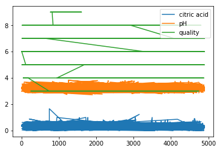

```python
quality_sorted = quality_sorted
quality_sorted.plot()
```

### Creating data frames

You can also create data frames in pandas:

|  | A | B | C |
| --- | --- | --- | --- |
| 2000-01-01 | 0.925911 | 0.826709 | 1.265237 |
| 2000-01-02 | 1.238019 | -1.119733 | -0.936616 |
| 2000-01-03 | -0.898996 | -1.347025 | -0.604194 |
| 2000-01-04 | 0.717334 | -0.597611 | -1.444401 |
| 2000-01-05 | 1.718913 | -2.318578 | -0.250939 |

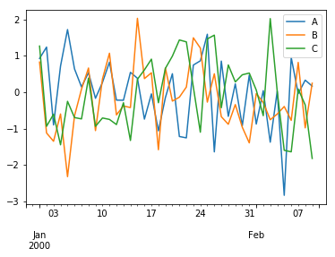

```python
index = pd.date_range('1/1/2000', periods=40)
s = pd.Series(np.random.randn(5), index=['a', 'b', 'c', 'd', 'e'])

df = pd.DataFrame(np.random.randn(40, 3), index=index, columns=['A', 'B', 'C'])
display(df.head())
df.plot()
```